# 7-Blood-enrichment-analysis.RMD

Ana BVA

23 December 2020

## Introduction

We previously had run the following scripts:

- 1: Dowload RAW data `/1-Blood-download_raw-data.RMD`
- 2: Normalizing data `/2-Blood-normalizing-data.RMD`
- 3: Curating data `/3-Blood-curatig-data.RMD`
- 4: Differential gene expression analysis `/4-Blood-DE.RMD`
- 5: Merging data `/5-Blood-merge-data.RMD`
- 6: Merging data `/6-Blood-meta-analysis.RMD`

## Input

This script needs the following files:

**Data:** Meta-analysis results in `csv` files

## Analysis

### Setup

For running the script, type:

```bash
ssh -X aaltamirano@dna.lavis.unam.mx
qrsh
cd /home/ana/DataDNA/R-projects/Meta-analysis_COPD/Blood/output_data/.out
 module load r/4.0.1

nohup R -e "rmarkdown::render(here::here('Blood/vignettes/7-Blood-enrichment-pathways.RMD'))" > 7-Blood-enrichment-pathways.RMD &
```

The script can be found in: /Users/user/Documents/Doctorado/Analysis/Meta-analysis_COPD/Blood/vignettes. And the directories were set using `R/setup.R` (e.i. DATA, OUPUT, DOWNLOAD) as a small functions that will paste the names into complete paths.

```r
knitr::opts_knit$set(root.dir = here::here())
source(here::here("Blood/R/setup.R"))
```

And this analysis is run in: /Users/user/Documents/Doctorado/Analysis/Meta-analysis_COPD

### Libraries

```r
library(hypeR)
library(WGCNA)
library(tidyverse)
library(reactable)
```

### Import data

We will import DE results from all experiments.

```r
meta <- read_csv(OUTPUT("2020-11-30_Step6_meta-analysis.csv"))[,-1]
meta
```

```
## # A tibble: 41,093 x 10
##    genes          QEp estimate    pval     se    H2    tau2    I2 num_exp   qval
##    <chr>        <dbl>    <dbl>   <dbl>  <dbl> <dbl>   <dbl> <dbl>   <dbl>  <dbl>
##  1 PRELID1   1.20e- 2   0.135  9.35e-4 0.0408  2.85 0.00465  64.9       5 0.0198
##  2 SGMS2     2.18e- 3   0.301  2.31e-2 0.132   9.32 0.0671   89.3       5 0.176
##  3 PID1      1.74e- 3   0.196  1.26e-1 0.128   8.47 0.0654   88.2       5 0.453
##  4 PRRC2C    4.63e- 6  -0.0526 4.57e-1 0.0708  7.35 0.0194   86.4       5 0.772
##  5 MGST1     1.20e- 3   0.185  1.71e-1 0.136   8.14 0.0772   87.7       5 0.522
##  6 ACE       1.88e- 5  -0.108  3.59e-1 0.118  15.3  0.0551   93.5       5 0.706
##  7 SOGA1     1.59e- 6  -0.0835 3.86e-1 0.0964 13.9  0.0376   92.8       5 0.726
##  8 SLPI      9.81e-10   0.262  4.06e-1 0.315  29.3  0.463    96.6       5 0.738
##  9 CD36      9.77e- 5   0.270  9.75e-2 0.163  32.4  0.115    96.9       5 0.398
## 10 ARMC2-AS1 3.04e- 3   0.207  6.33e-2 0.111   6.35 0.0281   84.3       3 0.316
## # … with 41,083 more rows
```

### Ranking and weighted values

```r
qval_cutoff <- 0.5

df <- meta %>%
  filter(qval <= qval_cutoff & meta$num_exp > 2)  %>%
  dplyr::arrange(desc(estimate))

signature <- as.vector(df$estimate)
names(signature) <- df$genes
head(signature)
```

```
##  HIST1H4H     KLRC1        GK    FCGR1A     NAMPT      CD86
## 0.4849149 0.4830651 0.4598197 0.4075581 0.4058066 0.4010573
```

```r
# KEGG
KEGG <- hyperdb_rgsets("KEGG", "92.0")

#HALLMARL
HALLMARK <- msigdb_gsets(species="Homo sapiens", category="H",clean = T)

#ENRICHR
TF_TJ <- enrichr_gsets("TRANSFAC_and_JASPAR_PWMs")

enrichR<- enrichr_gsets("Jensen_DISEASES")

enrichR<- enrichr_gsets("Jensen_TISSUES")

enrichR<- enrichr_gsets("Chromosome_Location")

enrichR<- enrichr_gsets("WikiPathways_2019_Human")

enrichR<- enrichr_gsets("ClinVar_2019")
```

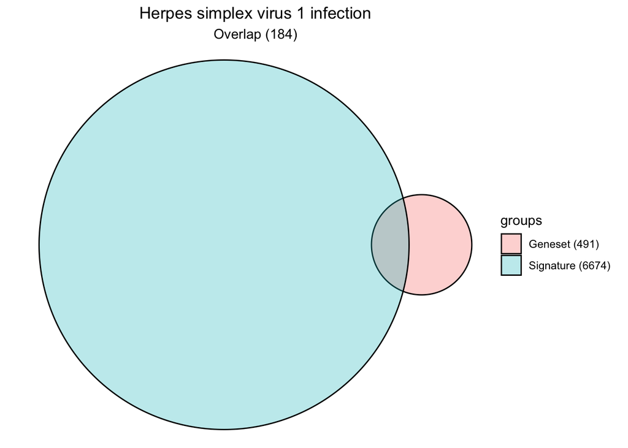

```r
KEGG <- hyperdb_rgsets("KEGG", "92.0")

DB <- KEGG
  # Ranked Signature using the estimator from the meta analysis (FC)
  hyp_obj <- hypeR(names(signature),DB, test="hypergeometric", background=nrow(meta), fdr=0.5, plotting=TRUE)
  hyp_obj$plots[[1]]
```

```r
  hyp_obj
```

```
## (hyp)
##
##   data:
##                             label    pval     fdr signature geneset overlap
##  Herpes simplex virus 1 infection 3.0e-30 9.1e-28      6674     491     184
##                Pathways in cancer 1.7e-25 2.6e-23      6674     531     184
##                          Lysosome 9.7e-18 9.7e-16      6674     123      61
##        PI3K-Akt signaling pathway 3.2e-14 2.4e-12      6674     354     115
##                      Tuberculosis 2.5e-13 1.3e-11      6674     180      70
##                         Apoptosis 2.7e-13 1.3e-11      6674     136      58
##  background
##       41093
##       41093
##       41093
##       41093
##       41093
##       41093
##                                                                                                                                                                                                                                                                                                          …
##  LTA,TRAF5,IKBKB,NFKBIA,RELA,BIRC3,PILRA,ITGA5,CARD9,TP53,C5,CFP,TLR2,MYD88,TRAF6,IL1B,IL6,DDX58,TRAF3,IFNA5,OAS1,RNASEL,HCFC1,POU2F3,IFNAR1,STAT1,STAT2,ZNF595,ZNF425,ZNF782,ZNF519,ZNF610,ZNF320,ZNF791,ZNF709,ZNF383,ZNF540,ZNF675,ZFP30,ZNF510,ZNF718,ZNF549,ZNF337,ZNF285,ZNF544,ZIK1,ZFP82,ZNF256,Z…
##                                                                                                                                         CASP9,APPL1,CTNNA1,AXIN2,APC,TCF7,TCF7L1,LEF1,BIRC5,MYC,WNT2B,WNT5B,WNT7A,FZD1,FZD7,FZD2,FZD3,FZD4,FZD6,FZD10,LRP5,LRP6,DVL3,DVL2,DVL1,FRAT1,FRAT2,F2R,LPAR3,LPAR…
##                                                                                                                                                                                                                                                                                                          …
##                                                                                                                                                                                                                                                                                                          …
##                                                                                                                                                                                                                                                                                                          …
##                                                                                                                                                                                                                                                                                                          …
##
##   plots: 289 Figures
##
##   args: signature
##         genesets
##         test
##         background
##         power
##         absolute
##         pval
##         fdr
##         plotting
##         quiet
```

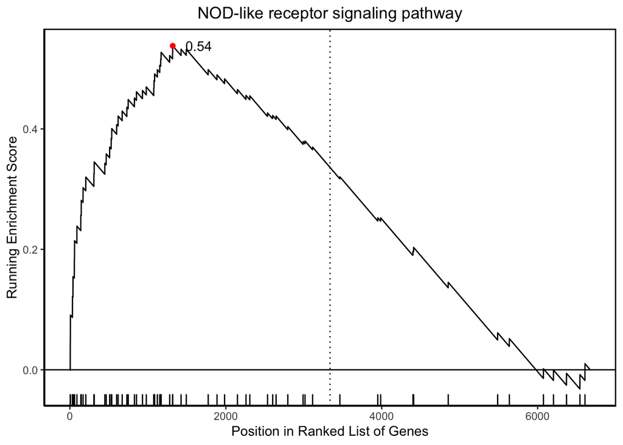

```r
  # Weighted Signature using as ranking the estimator and the weighted the qvalue
  hyp_obj <- hypeR(signature, DB, test="kstest", background=nrow(meta),fdr=0.5, plotting=TRUE)
  hyp_obj$plots[[1]]
```

```r
  hyp_obj
```

```
## (hyp)
##
##   data:
##                                label    pval     fdr signature geneset overlap
##  NOD-like receptor signaling pathway 1.2e-08 3.6e-06      6674     181      65
##                             Lysosome 3.6e-08 5.0e-06      6674     123      61
##                            Phagosome 5.0e-08 5.0e-06      6674     152      58
##           Osteoclast differentiation 2.6e-06 2.0e-04      6674     128      53
##                         Tuberculosis 9.9e-06 6.0e-04      6674     180      70
##                        Legionellosis 1.2e-05 6.0e-04      6674      57      24
##  score
##   0.38
##   0.38
##   0.38
##   0.35
##   0.29
##   0.49
##
##   plots: 204 Figures
##
##   args: signature
##         genesets
##         test
##         background
##         power
##         absolute
##         pval
##         fdr
##         plotting
##         quiet
```

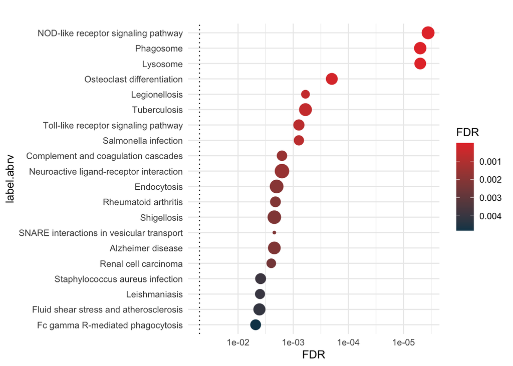

```r
  # Show interactive table
  #hyp_show(hyp_obj)

  # Plot dots plot
  hyp_dots(hyp_obj) + theme_minimal()
```

```r
  # Plot enrichment map
  #hyp_emap(hyp_obj)

  # Plot hiearchy map
  #hyp_hmap(hyp_obj)

  # Generate markdown report
  #hyp_to_rmd(hyp_obj,"hypr-KEGG-genesets.rmd")
  #hyp_to_rmd(hyp_obj,"hypr-TRANSFAC_and_JASPAR_PWMs.rmd")
```

```r
HALLMARK <- msigdb_gsets(species="Homo sapiens", category="H",clean = T)
```

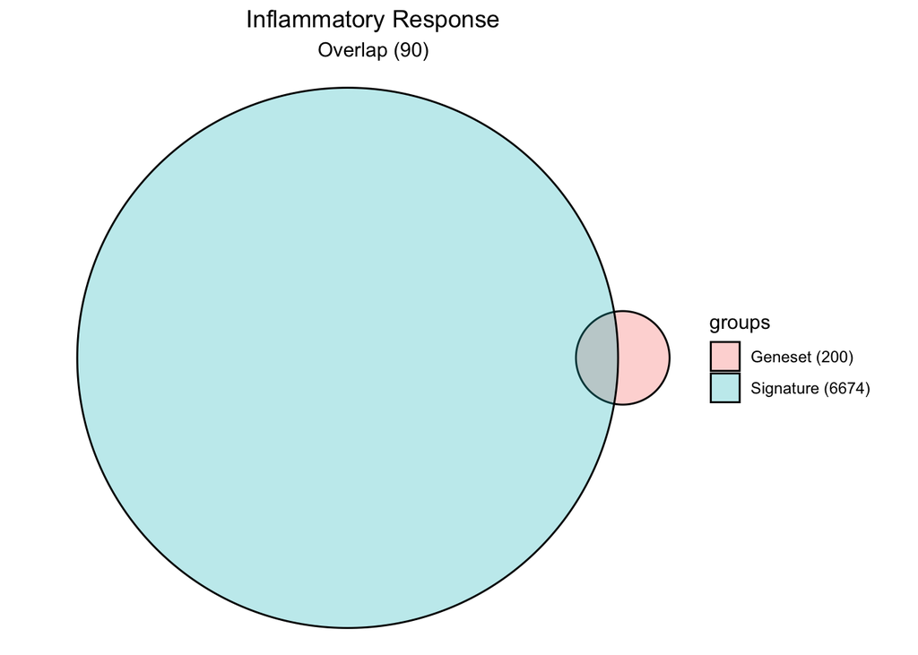

```r
DB <- HALLMARK
  # Ranked Signature using the estimator from the meta analysis (FC)
  hyp_obj <- hypeR(names(signature),DB, test="hypergeometric", background=nrow(meta), fdr=0.5, plotting=TRUE)
  hyp_obj$plots[[1]]
```

```r
  hyp_obj
```

```
## (hyp)
##
##   data:
##                    label    pval     fdr signature geneset overlap background
##    Inflammatory Response 1.0e-21 5.0e-20      6674     200      90      41093
##              E2f Targets 2.9e-19 7.2e-18      6674     200      86      41093
##               Complement 4.4e-18 7.3e-17      6674     200      84      41093
##          Mitotic Spindle 1.1e-17 1.4e-16      6674     199      83      41093
##  Tnfa Signaling Via Nfkb 1.6e-17 1.6e-16      6674     200      83      41093
##                Apoptosis 7.0e-17 5.9e-16      6674     161      71      41093
##                                                                                                                                                                                                                                                                                                          …
##  ABCA1,ACVR1B,ADM,ADORA2B,AHR,AQP9,BEST1,BST2,C3AR1,CALCRL,CCR7,CCRL2,CD14,CD40,CD55,CLEC5A,CSF3R,CX3CL1,CXCR6,CYBB,FFAR2,FPR1,GABBR1,GNA15,HPN,HRH1,ICAM1,IFNAR1,IFNGR2,IL10,IL10RA,IL18,IL1A,IL1B,IL1R1,IL2RB,IL6,IL7R,INHBA,IRAK2,ITGA5,KCNA3,KCNJ2,KIF1B,KLF6,LCK,LCP2,LDLR,LTA,MARCO,MEFV,MSR1,MXD1,…
##                       ASF1B,ATAD2,AURKB,BIRC5,BRCA1,BRCA2,CBX5,CCNB2,CDC20,CDC25B,CDCA3,CDCA8,CDK1,CDK4,CDKN1B,CDKN2C,CKS2,CTCF,CTPS1,DCLRE1B,DCTPP1,DDX39A,DIAPH3,DLGAP5,DNMT1,ESPL1,GINS3,GSPT1,HELLS,HMGB2,HMMR,ILF3,KIF22,KIF2C,KIF4A,LIG1,LMNB1,LUC7L3,LYAR,MCM2,MCM3,MCM6,MELK,MKI67,MTHFD2,MYC,NAA…
##                                                       ADAM9,ADRA2B,ANG,ATOX1,C2,CASP1,CASP10,CASP4,CASP5,CASP9,CD36,CD40LG,CD55,CD59,CDA,CP,CPM,CPQ,CR1,CR2,CTSB,CTSD,CTSH,CTSL,CTSS,DGKG,DOCK10,DOCK4,DOCK9,DPP4,DYRK2,F8,FCER1G,FCN1,FYN,GATA3,GCA,GNAI2,GNB2,GNB4,GNGT2,GPD2,HPCAL4,IL6,ITGAM,ITIH1,JA…
##                 ALMS1,APC,ARHGAP5,ARHGEF3,ARHGEF7,ARL8A,BCL2L11,BCR,BIN1,BIRC5,BRCA2,BUB1,CCDC88A,CCNB2,CDC42BPA,CDC42EP1,CDC42EP2,CDC42EP4,CDK1,CDK5RAP2,CENPF,CENPJ,CEP72,CKAP5,CLIP1,CLIP2,CNTRL,DLG1,DLGAP5,DOCK4,DYNLL2,ECT2,EPB41L2,ESPL1,EZR,FBXO5,FGD4,FLNB,FSCN1,GEMIN4,GSN,HOOK3,ITSN1,KIF11,KI…
##                               ABCA1,ACKR3,B4GALT1,B4GALT5,BCL2A1,BCL6,BIRC3,BMP2,CCNL1,CCRL2,CD83,CEBPD,DDX58,DRAM1,DUSP1,DUSP2,DUSP4,ETS2,F2RL1,FJX1,FUT4,GADD45A,GADD45B,HES1,ICAM1,IER3,IFIT2,IFNGR2,IL18,IL1A,IL1B,IL23A,IL6,IL7R,INHBA,IRS2,JUNB,KLF4,KLF6,KYNU,LDLR,MAFF,MAP3K8,MARCKS,MCL1,MXD1,MY…
##                                                                                                                 AIFM3,ANKH,ANXA1,BAX,BCL2L1,BCL2L11,BCL2L2,BGN,BID,BIRC3,BMP2,BRCA1,CASP1,CASP4,CASP6,CASP9,CCNA1,CCND2,CD14,CD2,CDC25B,CDKN1B,DDIT3,DFFA,DIABLO,DNAJA1,ENO2,ERBB2,F2R,FASLG,GADD45A,GADD…
##
##   plots: 50 Figures
##
##   args: signature
##         genesets
##         test
##         background
##         power
##         absolute
##         pval
##         fdr
##         plotting
##         quiet
```

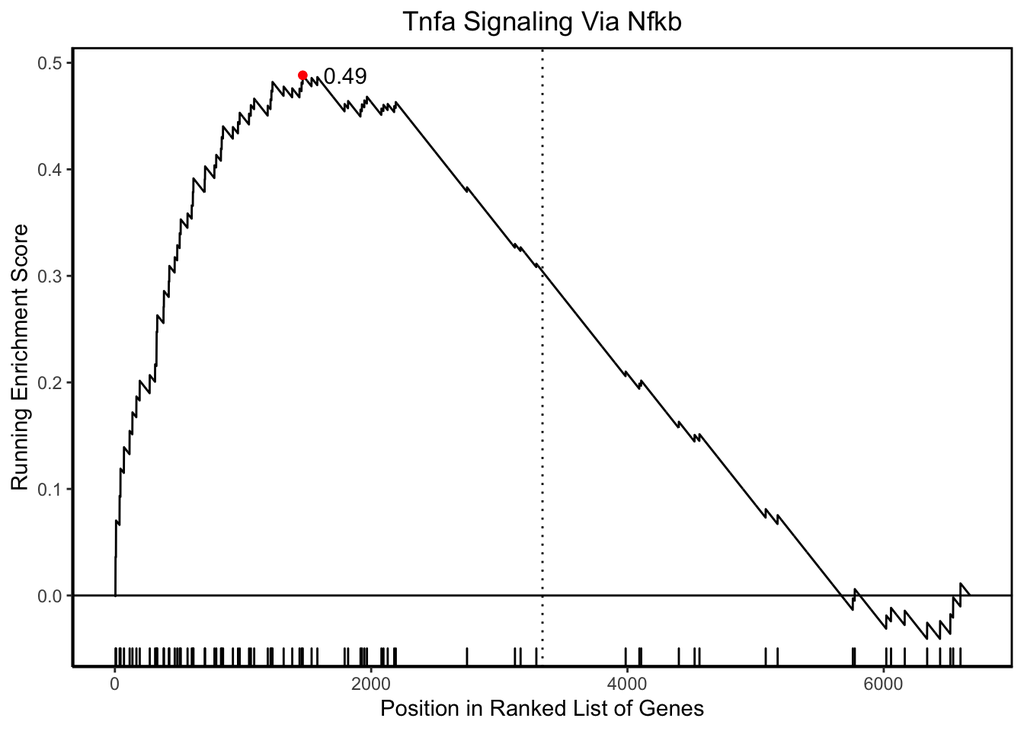

```r
  # Weighted Signature using as ranking the estimator and the weighted the qvalue
  hyp_obj <- hypeR(signature, DB, test="kstest", background=nrow(meta),fdr=0.5, plotting=TRUE)
  hyp_obj$plots[[1]]
```

```r
  hyp_obj
```

```
## (hyp)
##
##   data:
##                      label    pval     fdr signature geneset overlap score
##    Tnfa Signaling Via Nfkb 1.7e-12 8.5e-11      6674     200      83  0.41
##  Interferon Gamma Response 1.5e-10 3.8e-09      6674     200      75  0.39
##                 Complement 4.6e-10 7.1e-09      6674     200      84  0.36
##      Inflammatory Response 5.7e-10 7.1e-09      6674     200      90  0.35
##  Interferon Alpha Response 1.2e-09 1.2e-08      6674      97      34  0.55
##    Il6 Jak Stat3 Signaling 2.5e-06 2.1e-05      6674      87      30  0.46
##
##   plots: 42 Figures
##
##   args: signature
##         genesets
##         test
##         background
##         power
##         absolute
##         pval
##         fdr
##         plotting
##         quiet
```

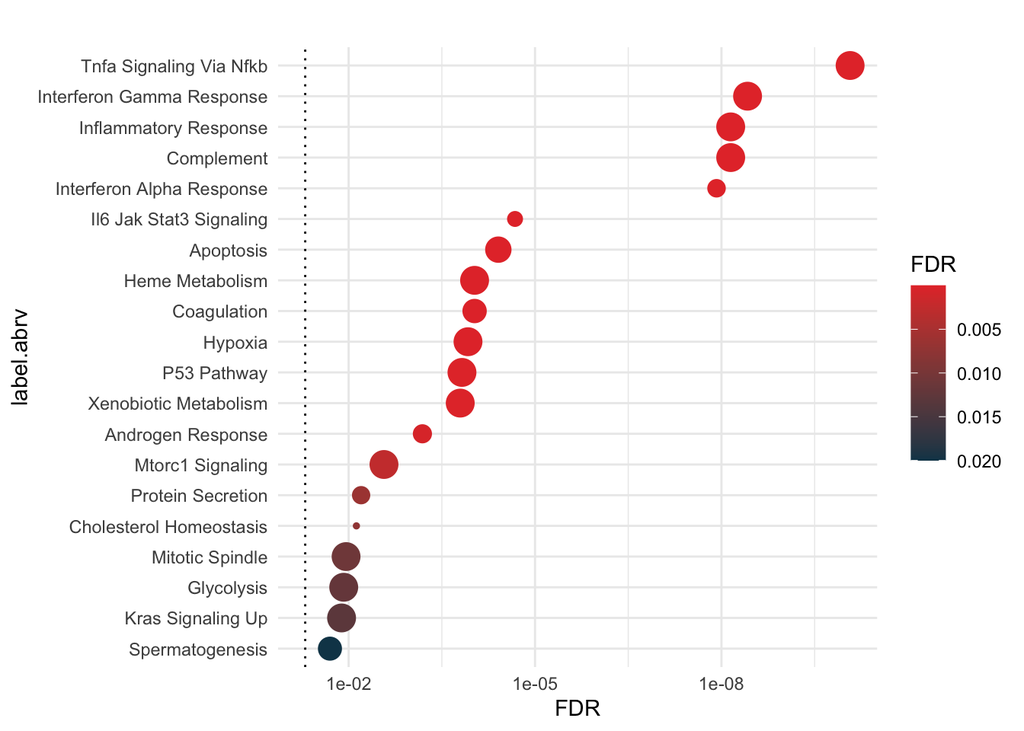

```r
  # Show interactive table
  #hyp_show(hyp_obj)

  # Plot dots plot
  hyp_dots(hyp_obj) + theme_minimal()
```

```r
  # Plot enrichment map
  #hyp_emap(hyp_obj)

  # Plot hiearchy map
  #hyp_hmap(hyp_obj)

  # Generate markdown report
  #hyp_to_rmd(hyp_obj,"hypr-KEGG-genesets.rmd")
  #hyp_to_rmd(hyp_obj,"hypr-TRANSFAC_and_JASPAR_PWMs.rmd")
```

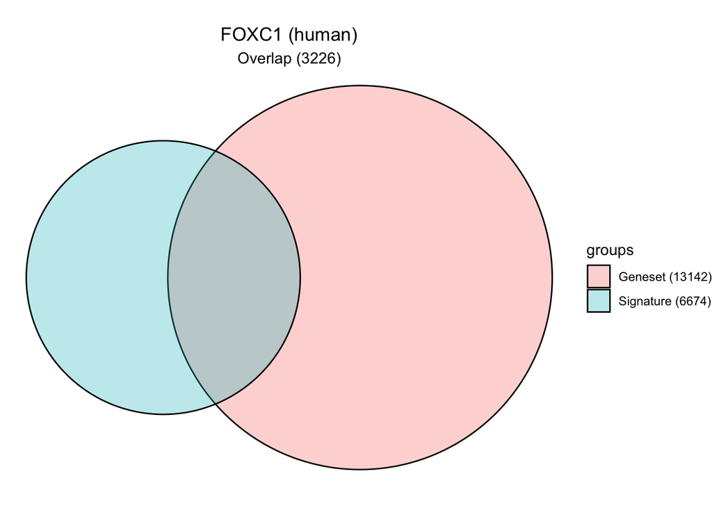

```r
TF_TJ <- enrichr_gsets("TRANSFAC_and_JASPAR_PWMs")
DB <- TF_TJ
  # Ranked Signature using the estimator from the meta analysis (FC)
  hyp_obj <- hypeR(names(signature),DB, test="hypergeometric", background=nrow(meta), fdr=0.5, plotting=TRUE)
  hyp_obj$plots[[1]]
```

```r
  hyp_obj
```

```
## (hyp)
##
##   data:
##          label     pval      fdr signature geneset overlap background
##  FOXC1 (human) 1.7e-204 5.7e-202      6674   13142    3226      41093
##  GATA2 (human) 1.1e-131 1.7e-129      6674    9985    2433      41093
##   LEF1 (human) 5.8e-123 6.3e-121      6674    4658    1356      41093
##   E2F1 (human) 1.9e-115 1.5e-113      6674    4207    1240      41093
##   TCF4 (human) 1.4e-103 8.9e-102      6674    4210    1209      41093
##  NR5A2 (human)  1.7e-94  9.2e-93      6674    3815    1100      41093
##                                                                                                                                                                                                                                                                                                          …
##  BAD,AGTR1,BBX,NEBL,VPS13D,PKIA,STRN,COL13A1,FAM19A5,GSTM5,MYBPC1,MBD5,MBD2,GSTO1,ADAM12,ADAM17,NEFM,BID,FADS1,RASL10B,FBXO17,PKP2,RASL11B,NPAS2,STX7,STX6,BCAS4,NEK6,FBXO38,PIAS1,FBXO34,FBXO31,FBXO32,BCAT1,KCNE1,KCNE3,ZC4H2,GSTT1,FBXO21,GOLIM4,TNFRSF8,NEK2,NEK3,KCNJ9,HTR1D,HTR1E,KCNK6,ONECUT1,SHM…
##                                                                                                                                                                                                                                                                                                          …
##                                                                                                                                                                                                                                                                                                          …
##                                                                                                                                                                                                                                                                                                          …
##                                                                                                                                                                                                                                                                                                          …
##                                                                                                                                                                                                                                                                                                          …
##
##   plots: 309 Figures
##
##   args: signature
##         genesets
##         test
##         background
##         power
##         absolute
##         pval
##         fdr
##         plotting
##         quiet
```

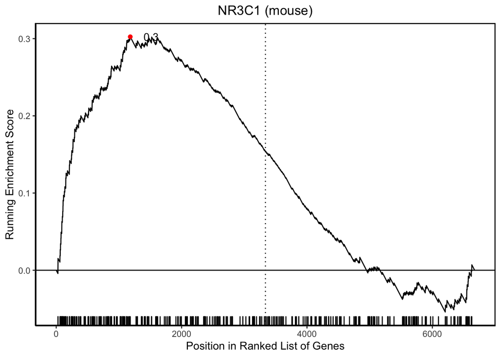

```r
  # Weighted Signature using as ranking the estimator and the weighted the qvalue
  hyp_obj <- hypeR(signature, DB, test="kstest", background=nrow(meta),fdr=0.5, plotting=TRUE)
  hyp_obj$plots[[1]]
```

```r
  hyp_obj
```

```
## (hyp)
##
##   data:
##          label    pval    fdr signature geneset overlap score
##  NR3C1 (mouse) 1.1e-05 0.0036      6674    1775     306 0.140
##  NR5A2 (human) 2.7e-05 0.0044      6674    3815    1100 0.075
##  KLF11 (human) 2.4e-04 0.0240      6674    1388     370 0.110
##    REL (mouse) 2.9e-04 0.0240      6674    1752     419 0.100
##  CEBPB (human) 5.0e-04 0.0290      6674    1420     410 0.099
##   SPI1 (mouse) 5.9e-04 0.0290      6674    1680     393 0.100
##
##   plots: 173 Figures
##
##   args: signature
##         genesets
##         test
##         background
##         power
##         absolute
##         pval
##         fdr
##         plotting
##         quiet
```

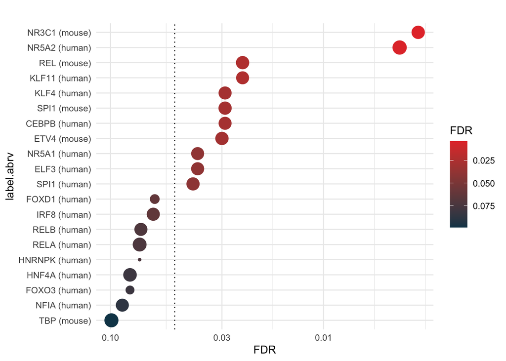

```r
  # Show interactive table
  #hyp_show(hyp_obj)

  # Plot dots plot
  hyp_dots(hyp_obj) + theme_minimal()
```

```r
  # Plot enrichment map
  #hyp_emap(hyp_obj)

  # Plot hiearchy map
  #hyp_hmap(hyp_obj)

  # Generate markdown report
  #hyp_to_rmd(hyp_obj,"hypr-KEGG-genesets.rmd")
  #hyp_to_rmd(hyp_obj,"hypr-TRANSFAC_and_JASPAR_PWMs.rmd")
```

## Output

This script produces the following data, and can be found in /Users/user/Documents/Doctorado/Analysis/Meta-analysis_COPD

**Figures in the vignette:** Enrichment analysis with plots